# Homework_10.Rmd

Molly Ratliff

2024-04-03

## R Markdown

**1.Using a for loop, write a function to calculate the number of zeroes in a numeric vector. Before entering the loop, set up a counter variable counter <- 0. Inside the loop, add 1 to counter each time you have a zero in the vector. Finally, use return(counter) for the output.**

```r
myVec <- (rbinom(n=5,size=1,prob=0.5))
counter <- 0

for (i in seq_along(myVec)){
  if(myVec[i]==0) {
  counter <- counter + 1
  }
}
print(counter)
```

```
## [1] 2
```

**2. Use subsetting instead of a loop to rewrite the function as a single line of code.**

```r
countZeros <- function(myVec) {
  counter <- 0
  for (i in seq_along(myVec)) {
    if (myVec[i] == 0) {
      counter <- counter + 1
    }
  }
  return(counter)
}
countZeros(myVec)
```

```
## [1] 2
```

**3. Write a function that takes as input two integers representing the number of rows and columns in a matrix. The output is a matrix of these dimensions in which each element is the product of the row number x the column number.**

```r
m <- matrix(round(runif(12),digits=1),nrow=3)
multiplyMatrix <- function(m) {
  for (i in 1:nrow(m)) {
    for (j in 1:ncol(m)) {
      m[i,j] <- m[i,j] * m[i,j]
    }
  }
return(m)
}
multiplyMatrix(m)
```

```
##      [,1] [,2] [,3] [,4]
## [1,] 0.01 0.36 0.81 0.25
## [2,] 0.04 0.04 0.36 0.36
## [3,] 1.00 0.64 0.81 0.81
```

**4a. Simulate a dataset with 3 groups of data, each group drawn from a distribution with a different mean. The final data frame should have 1 column for group and 1 column for the response variable.**

```r
plotApH <- rnorm(n=10, mean=9, sd=0.5)
plotBpH <- rnorm(n=10, mean=7, sd=0.5)
plotCpH <- rnorm(n=10, mean=6, sd=0.5)
pH <- data.frame(plotApH, plotBpH, plotCpH)
pH <- pH %>%
  pivot_longer(cols=1:3, names_to="TreatmentGroup",values_to="MeanpH",values_drop_na=T)
print(pH)
```

```
## # A tibble: 30 × 2
##    TreatmentGroup MeanpH
##    <chr>           <dbl>
##  1 plotApH          8.79
##  2 plotBpH          6.28
##  3 plotCpH          6.00
##  4 plotApH          8.75
##  5 plotBpH          6.92
##  6 plotCpH          6.76
##  7 plotApH          8.82
##  8 plotBpH          7.08
##  9 plotCpH          6.60
## 10 plotApH          9.42
## # ℹ 20 more rows
```

**4b. Write a custom function that 1) reshuffles the response variable, and 2) calculates the mean of each group in the reshuffled data. Store the means in a vector of length 3.**

```r
shuffle <- function(pH){
  plotApH <- rnorm(n=10, mean=9, sd=0.5)
  plotBpH <- rnorm(n=10, mean=7, sd=0.5)
  plotCpH <- rnorm(n=10, mean=6, sd=0.5)
  pH <- data.frame(plotApH, plotBpH, plotCpH)
  pH <- pH %>%
    pivot_longer(cols=1:3, names_to="TreatmentGroup",values_to="MeanpH",values_drop_na=T)
  pHGroups <- group_by(pH, TreatmentGroup)
  pHdata <- c(summarize(pHGroups, meanpH=mean(MeanpH, na.rm=TRUE)))
  means <- pHdata$meanpH
  return(means)
}
shuffle(pH)
```

```
## [1] 8.943718 6.750853 6.175068
```

**4c. Use a for loop to repeat the function in b 100 times. Store the results in a data frame that has 1 column indicating the replicate number and 1 column for each new group mean, for a total of 4 columns.**

```r
results <- data.frame(replicate = 1:100)
for (i in 1:100) {
  results[i, 2:4] <- shuffle()
}
print(results)
```

```
##     replicate       V2       V3       V4
## 1           1 8.943928 6.944996 5.972025
## 2           2 8.956901 6.989348 5.888210
## 3           3 9.241666 7.018141 6.381692
## 4           4 9.267089 7.085129 5.899073
## 5           5 8.856140 6.662050 6.117810
## 6           6 9.065393 6.747755 6.031621
## 7           7 9.000028 7.272503 6.006395
## 8           8 9.156634 6.967040 6.257657
## 9           9 9.086503 6.937152 6.044499
## 10         10 8.947550 7.029396 6.017362
## 11         11 9.006983 6.973798 6.053756
## 12         12 9.220158 6.957595 5.984956
## 13         13 9.107048 7.207913 5.794918
## 14         14 8.977316 6.903000 5.986195
```

[output cut: 86 more lines]

**4d. Use qplot() to create a histogram of the means for each reshuffled group. Or, if you want a challenge, use ggplot() to overlay all 3 histograms in the same figure. How do the distributions of reshuffled means compare to the original means?**

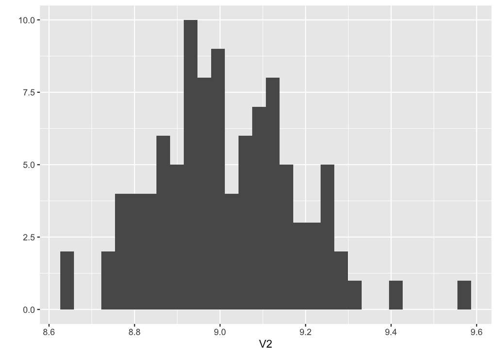

```r
qplot(data = results, x = V2, geom = "histogram")
```

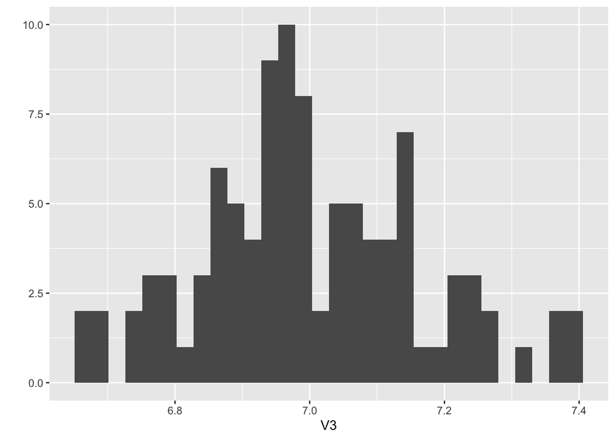

```r
qplot(data = results, x = V3, geom = "histogram")
```

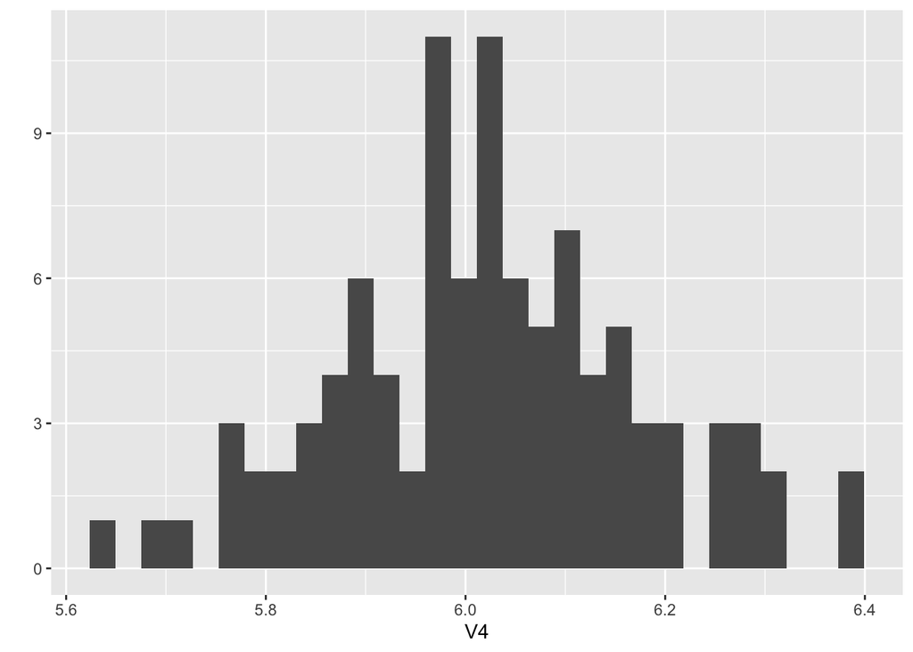

```r
qplot(data = results, x = V4, geom = "histogram")
```

The distributions of the shuffled means are similar to the original means. They are all centered around the original means with a relatively normal distribution.